# ridge_lasso

### Sample notebook for multiple linear regression (MLR) for Abalone data

アワビデータの重回帰分析の手順例

Data: https://archive.ics.uci.edu/ml/machine-learning-databases/abalone/  
Abalone Data (modified: some data are replaced by N/A):

Sex / nominal / -- / M, F, and I (infant)  
Length / continuous / mm / Longest shell measurement  
Diameter / continuous / mm / perpendicular to length  
Height / continuous / mm / with meat in shell  
Whole weight / continuous / grams / whole abalone  
Shucked weight / continuous / grams / weight of meat  
Viscera weight / continuous / grams / gut weight (after bleeding)  
Shell weight / continuous / grams / after being dried  
Rings / integer / -- / +1.5 gives the age in years

#### Import libraries

```python
import sys
import numpy as np
import pandas as pd
from pandas.plotting import scatter_matrix
import seaborn as sns
import matplotlib.pyplot as plt
from sklearn import preprocessing
import statsmodels.api as sm
import statsmodels.formula.api as smf
```

#### Parameters

```python
%config InlineBackend.figure_formats = {'png', 'retina'} #high-reso images
plt.rcParams['font.family'] = 'Yu Mincho' # for Japanese in graph (Win10)

# To show all rows and columns in the results
pd.options.display.max_rows = 999
pd.options.display.max_columns = 999
```

#### Step 1. Collect possible explanatory variables

目的変数に影響を与えていそうな要因は、可能な限り網羅的に説明変数に取り入れる。

##### Check & read CSV file, replace column labels if needed, etc.

encoding='shift-jis' may be needed.  
CSVファイルをチェックしてから読み込む。必要に応じて列ラベルを変更。  
CSVファイルの漢字コードがShift-JISの場合は encoding='shift-jis' が必要。

```python
csv_in = 'abalone_modified.csv'
df_all = pd.read_csv(csv_in, delimiter=',', skiprows=0, header=None)
# no header in csv, so set columns explicitly
df_all.columns = ['sex', 'len', 'd', 'h', 'w_all', 'w_meat', 'w_gut', 'w_shell', 'ring']
print(df_all.shape)
print(df_all.info())
display(df_all.head())
```

```
(4177, 9)
<class 'pandas.core.frame.DataFrame'>
RangeIndex: 4177 entries, 0 to 4176
Data columns (total 9 columns):
 #   Column   Non-Null Count  Dtype
---  ------   --------------  -----
 0   sex      4177 non-null   object
 1   len      4177 non-null   float64
 2   d        4176 non-null   float64
 3   h        4177 non-null   float64
 4   w_all    4175 non-null   float64
 5   w_meat   4177 non-null   float64
 6   w_gut    4177 non-null   float64
 7   w_shell  4177 non-null   float64
 8   ring     4177 non-null   int64
dtypes: float64(7), int64(1), object(1)
memory usage: 293.8+ KB
None
```

|  | sex | len | d | h | w_all | w_meat | w_gut | w_shell | ring |
| --- | --- | --- | --- | --- | --- | --- | --- | --- | --- |
| 0 | M | 0.455 | 0.365 | 0.095 | 0.5140 | 0.2245 | 0.1010 | 0.150 | 15 |
| 1 | M | 0.350 | 0.265 | 0.090 | 0.2255 | 0.0995 | 0.0485 | 0.070 | 7 |
| 2 | F | 0.530 | 0.420 | 0.135 | 0.6770 | 0.2565 | 0.1415 | 0.210 | 9 |
| 3 | M | 0.440 | NaN | 0.125 | 0.5160 | 0.2155 | 0.1140 | 0.155 | 10 |
| 4 | I | 0.330 | 0.255 | 0.080 | 0.2050 | 0.0895 | 0.0395 | 0.055 | 7 |

##### Check numerical / category variables if needed

数値列・カテゴリー列の様子をみる

```python
display(df_all.describe())
display(df_all.describe(exclude='number'))
```

|  | len | d | h | w_all | w_meat | w_gut | w_shell | ring |
| --- | --- | --- | --- | --- | --- | --- | --- | --- |
| count | 4177.000000 | 4176.000000 | 4177.000000 | 4175.000000 | 4177.000000 | 4177.000000 | 4177.000000 | 4177.000000 |
| mean | 0.523992 | 0.407892 | 0.139516 | 0.828871 | 0.359367 | 0.180594 | 0.238831 | 9.933684 |
| std | 0.120093 | 0.099250 | 0.041827 | 0.490450 | 0.221963 | 0.109614 | 0.139203 | 3.224169 |
| min | 0.075000 | 0.055000 | 0.000000 | 0.002000 | 0.001000 | 0.000500 | 0.001500 | 1.000000 |
| 25% | 0.450000 | 0.350000 | 0.115000 | 0.441750 | 0.186000 | 0.093500 | 0.130000 | 8.000000 |
| 50% | 0.545000 | 0.425000 | 0.140000 | 0.800000 | 0.336000 | 0.171000 | 0.234000 | 9.000000 |
| 75% | 0.615000 | 0.480000 | 0.165000 | 1.153500 | 0.502000 | 0.253000 | 0.329000 | 11.000000 |
| max | 0.815000 | 0.650000 | 1.130000 | 2.825500 | 1.488000 | 0.760000 | 1.005000 | 29.000000 |

|  | sex |
| --- | --- |
| count | 4177 |
| unique | 3 |
| top | M |
| freq | 1528 |

##### See rows including missing data

欠損値を含む行を表示してみる

```python
display(df_all[df_all.isnull().any(axis=1)])
```

|  | sex | len | d | h | w_all | w_meat | w_gut | w_shell | ring |
| --- | --- | --- | --- | --- | --- | --- | --- | --- | --- |
| 3 | M | 0.440 | NaN | 0.125 | 0.516 | 0.2155 | 0.1140 | 0.155 | 10 |
| 5 | I | 0.425 | 0.300 | 0.095 | NaN | 0.1410 | 0.0775 | 0.120 | 8 |
| 7 | F | 0.545 | 0.425 | 0.125 | NaN | 0.2940 | 0.1495 | 0.260 | 16 |

##### Delete rows including missing data, or fill missing data

欠損値を含む行を削除する (または欠損値を埋める)

```python
df_all = df_all.dropna().reset_index(drop=True)
#df_all = df_all.fillna(df_all.mean()) # if you want to fill missing data instead of deleting them
print(df_all.shape)
display(df_all.head())
```

```
(4174, 9)
```

|  | sex | len | d | h | w_all | w_meat | w_gut | w_shell | ring |
| --- | --- | --- | --- | --- | --- | --- | --- | --- | --- |
| 0 | M | 0.455 | 0.365 | 0.095 | 0.5140 | 0.2245 | 0.1010 | 0.150 | 15 |
| 1 | M | 0.350 | 0.265 | 0.090 | 0.2255 | 0.0995 | 0.0485 | 0.070 | 7 |
| 2 | F | 0.530 | 0.420 | 0.135 | 0.6770 | 0.2565 | 0.1415 | 0.210 | 9 |
| 3 | I | 0.330 | 0.255 | 0.080 | 0.2050 | 0.0895 | 0.0395 | 0.055 | 7 |
| 4 | F | 0.530 | 0.415 | 0.150 | 0.7775 | 0.2370 | 0.1415 | 0.330 | 20 |

##### Separate explanatory variables and objective variable

説明変数と目的変数を分ける

```python
X_all_org = df_all.loc[:, 'sex':'w_shell']  # explanatory variables
#X_all_org = df_all.drop(columns='ring')  # alternative way, もうひとつの書き方
y = df_all['ring']  # objective variable
print('X_all_org:', X_all_org.shape)
display(X_all_org.head())
print('y:', y.shape)
print(y.head())
```

```
X_all_org: (4174, 8)
```

|  | sex | len | d | h | w_all | w_meat | w_gut | w_shell |
| --- | --- | --- | --- | --- | --- | --- | --- | --- |
| 0 | M | 0.455 | 0.365 | 0.095 | 0.5140 | 0.2245 | 0.1010 | 0.150 |
| 1 | M | 0.350 | 0.265 | 0.090 | 0.2255 | 0.0995 | 0.0485 | 0.070 |
| 2 | F | 0.530 | 0.420 | 0.135 | 0.6770 | 0.2565 | 0.1415 | 0.210 |
| 3 | I | 0.330 | 0.255 | 0.080 | 0.2050 | 0.0895 | 0.0395 | 0.055 |
| 4 | F | 0.530 | 0.415 | 0.150 | 0.7775 | 0.2370 | 0.1415 | 0.330 |

```
y: (4174,)
0    15
1     7
2     9
3     7
4    20
Name: ring, dtype: int64
```

##### Apply get_dummies()

ダミー変数化

```python
X_all = pd.get_dummies(X_all_org, drop_first=True)
print('X_all:', X_all.shape)
display(X_all.head())
```

```
X_all: (4174, 9)
```

|  | len | d | h | w_all | w_meat | w_gut | w_shell | sex_I | sex_M |
| --- | --- | --- | --- | --- | --- | --- | --- | --- | --- |
| 0 | 0.455 | 0.365 | 0.095 | 0.5140 | 0.2245 | 0.1010 | 0.150 | 0 | 1 |
| 1 | 0.350 | 0.265 | 0.090 | 0.2255 | 0.0995 | 0.0485 | 0.070 | 0 | 1 |
| 2 | 0.530 | 0.420 | 0.135 | 0.6770 | 0.2565 | 0.1415 | 0.210 | 0 | 0 |
| 3 | 0.330 | 0.255 | 0.080 | 0.2050 | 0.0895 | 0.0395 | 0.055 | 1 | 0 |
| 4 | 0.530 | 0.415 | 0.150 | 0.7775 | 0.2370 | 0.1415 | 0.330 | 0 | 0 |

#### Step 2. Scatter plot and correlation coefficients between all combination of explanatory variables

変数間の総当たり散布図を描画。相関係数も算出しておく

##### all by all Pearson correlation coefficients;

総当たりのPearson相関係数

```python
corr_all = X_all.corr(method='pearson')
display(corr_all)
```

|  | len | d | h | w_all | w_meat | w_gut | w_shell | sex_I | sex_M |
| --- | --- | --- | --- | --- | --- | --- | --- | --- | --- |
| len | 1.000000 | 0.986824 | 0.827555 | 0.925252 | 0.897911 | 0.903016 | 0.897679 | -0.551546 | 0.236762 |
| d | 0.986824 | 1.000000 | 0.833662 | 0.925445 | 0.893159 | 0.899723 | 0.905311 | -0.564281 | 0.240469 |
| h | 0.827555 | 0.833662 | 1.000000 | 0.819178 | 0.774907 | 0.798264 | 0.817327 | -0.518572 | 0.215422 |
| w_all | 0.925252 | 0.925445 | 0.819178 | 1.000000 | 0.969399 | 0.966367 | 0.955353 | -0.557675 | 0.252168 |
| w_meat | 0.897911 | 0.893159 | 0.774907 | 0.969399 | 1.000000 | 0.931939 | 0.882607 | -0.521938 | 0.251896 |
| w_gut | 0.903016 | 0.899723 | 0.798264 | 0.966367 | 0.931939 | 1.000000 | 0.907653 | -0.556193 | 0.242286 |
| w_shell | 0.897679 | 0.905311 | 0.817327 | 0.955353 | 0.882607 | 0.907653 | 1.000000 | -0.547004 | 0.235566 |
| sex_I | -0.551546 | -0.564281 | -0.518572 | -0.557675 | -0.521938 | -0.556193 | -0.547004 | 1.000000 | -0.522557 |
| sex_M | 0.236762 | 0.240469 | 0.215422 | 0.252168 | 0.251896 | 0.242286 | 0.235566 | -0.522557 | 1.000000 |

##### Pickup explanatory variable pairs with large absolute value of correlation coefficient;

相関係数の絶対値が大きい説明変数ペアの出力

```python
th_corr = 0.3
keep = np.triu(np.ones(corr_all.shape), k=1).astype('bool').flatten()
triu = corr_all.stack()[keep]
triu_sorted = triu[ np.abs(triu).sort_values(ascending=False).index ]
print(triu_sorted[ (triu_sorted < -th_corr) | (triu_sorted > th_corr) ])
```

```
len      d          0.986824
w_all    w_meat     0.969399
         w_gut      0.966367
         w_shell    0.955353
w_meat   w_gut      0.931939
d        w_all      0.925445
len      w_all      0.925252
w_gut    w_shell    0.907653
d        w_shell    0.905311
len      w_gut      0.903016
d        w_gut      0.899723
len      w_meat     0.897911
         w_shell    0.897679
d        w_meat     0.893159
w_meat   w_shell    0.882607
d        h          0.833662
len      h          0.827555
h        w_all      0.819178
         w_shell    0.817327
         w_gut      0.798264
         w_meat     0.774907
d        sex_I     -0.564281
w_all    sex_I     -0.557675
w_gut    sex_I     -0.556193
len      sex_I     -0.551546
w_shell  sex_I     -0.547004
sex_I    sex_M     -0.522557
w_meat   sex_I     -0.521938
h        sex_I     -0.518572
dtype: float64
```

##### all by all scatter plots of explanatory variables;

変数間の総当たり散布図

seabornを使うなら

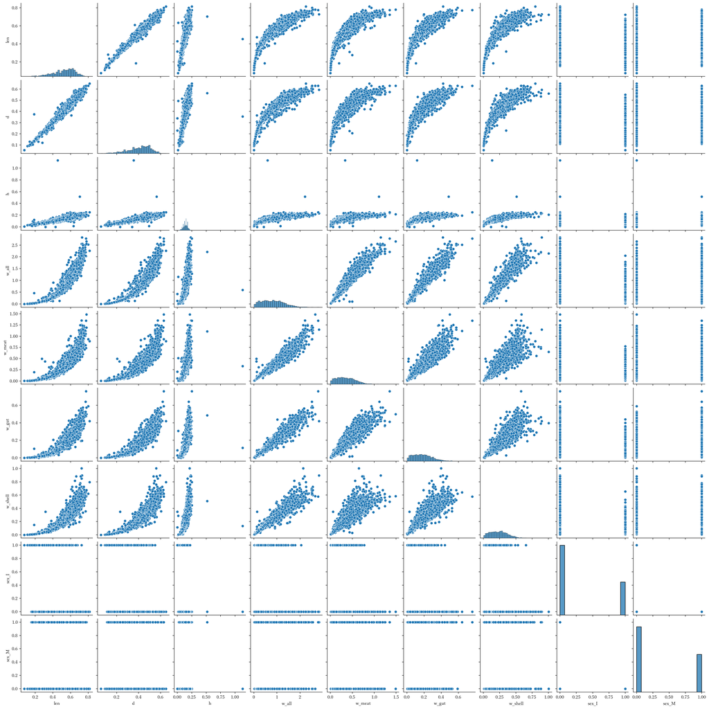

```python
sns.pairplot(X_all)
plt.show()
```

##### Heatmap

Heatmapを描いてもよい

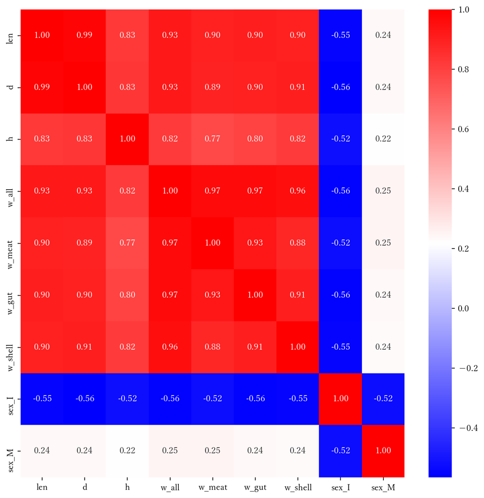

```python
plt.figure(figsize=(10,10))
sns.heatmap(corr_all,annot=True,fmt='.2f',cmap='bwr')
plt.show()
```

#### Step 3. MLR calculation using all variables

全説明変数を用いて、標準化なしで線形重回帰分析

```python
X_all_c = sm.add_constant(X_all)
model = sm.OLS(y, X_all_c)
results = model.fit()
print(results.summary())
```

```
                            OLS Regression Results
==============================================================================
Dep. Variable:                   ring   R-squared:                       0.538
Model:                            OLS   Adj. R-squared:                  0.537
Method:                 Least Squares   F-statistic:                     538.6
Date:                Sun, 28 Mar 2021   Prob (F-statistic):               0.00
Time:                        17:27:17   Log-Likelihood:                -9196.8
No. Observations:                4174   AIC:                         1.841e+04
Df Residuals:                    4164   BIC:                         1.848e+04
Df Model:                           9
Covariance Type:            nonrobust
==============================================================================
                 coef    std err          t      P>|t|      [0.025      0.975]
------------------------------------------------------------------------------
const          3.8927      0.292     13.352      0.000       3.321       4.464
len           -0.4806      1.810     -0.266      0.791      -4.029       3.068
d             11.0755      2.228      4.971      0.000       6.707      15.444
h             10.8085      1.536      7.036      0.000       7.797      13.820
w_all          8.9725      0.725     12.371      0.000       7.551      10.394
w_meat       -19.7779      0.817    -24.201      0.000     -21.380     -18.176
w_gut        -10.5529      1.294     -8.158      0.000     -13.089      -8.017
w_shell        8.7291      1.125      7.762      0.000       6.524      10.934
sex_I         -0.8202      0.102     -8.009      0.000      -1.021      -0.619
sex_M          0.0610      0.083      0.732      0.464      -0.102       0.224
==============================================================================
Omnibus:                      948.350   Durbin-Watson:                   1.438
Prob(Omnibus):                  0.000   Jarque-Bera (JB):             2721.642
Skew:                           1.182   Prob(JB):                         0.00
Kurtosis:                       6.172   Cond. No.                         137.
==============================================================================

Notes:
[1] Standard Errors assume that the covariance matrix of the errors is correctly specified.
```

#### Step 4. Check R2 and Adjusted R2 to see whether MLR is appropriate for this data

決定係数や自由度調整済み決定係数をみて、そもそも線形モデルの当てはめが妥当かどうかを判断

```python
print('R2:', results.rsquared)
print('Adj R2:', results.rsquared_adj)
```

```
R2: 0.5379311068528569
Adj R2: 0.5369323988705503
```

Not bad, but not good...

#### Step 5. Stat. test for MLR equation

重回帰式の検定 (求めた重回帰式は目的変数を説明している？)

```python
print('p-values (F-statistic)', results.f_pvalue)
```

```
p-values (F-statistic) 0.0
```

Very small p-value, so this MLR equation is considered to be significant.

#### Step 6-1. Standardization of variables

全説明変数と目的変数を標準化

```python
# NOTE: after scaling, X_scaled and Y_scaled are ndarray, not DataFrame.
X_scaled = preprocessing.scale(X_all)
dfX_scaled = pd.DataFrame(X_scaled, columns=X_all.columns)
y_scaled = preprocessing.scale(y)
dfy_scaled = pd.Series(y_scaled, name=y.name)
model = sm.OLS(dfy_scaled, dfX_scaled)
```

#### Step 6-1. Ridge regression

**Ridge回帰**

```python
results_ridge = model.fit_regularized(L1_wt=0.0, alpha=0.1)
print(results_ridge.params)
```

```
[ 8.67264430e-02  1.69975021e-01  1.66411896e-01  9.29007870e-02
 -4.20559039e-01 -5.48813906e-02  4.72631146e-01 -1.32165595e-01
  3.24747305e-04]
```

#### Step 6-2. LASSO regression

**LASSO回帰**

```python
results_lasso = model.fit_regularized(L1_wt=1.0, alpha=0.1)
print(results_lasso.params)
```

```
len        0.000000
d          0.000000
h          0.066691
w_all      0.000000
w_meat     0.000000
w_gut      0.000000
w_shell    0.440121
sex_I     -0.060572
sex_M      0.000000
dtype: float64
```

#### Step 6-3. Elastic Net regression

**Elastic Net**

```python
results_elastic = model.fit_regularized(L1_wt=0.5, alpha=0.1)
print(results_elastic.params)
```

```
len        0.000000
d          0.070624
h          0.124564
w_all      0.000000
w_meat    -0.132682
w_gut      0.000000
w_shell    0.452815
sex_I     -0.098112
sex_M      0.000000
dtype: float64
```

#### Step 7. Path plot to see which explanatory variables have large coefficients according to alpha

Explanatory variables with coefficients far from 0 have larger effect on objective variable.  
alpha値を変化させたときのどの説明変数の係数が大きいかを調べる。  
alphaを大きくしても係数が0にならない説明変数は目的変数への重要度が大きいと判断できる。

```python
alphas = 10 ** np.linspace(-3, 3, num=50)
print(alphas)
```

```
[1.00000000e-03 1.32571137e-03 1.75751062e-03 2.32995181e-03
 3.08884360e-03 4.09491506e-03 5.42867544e-03 7.19685673e-03
 9.54095476e-03 1.26485522e-02 1.67683294e-02 2.22299648e-02
 2.94705170e-02 3.90693994e-02 5.17947468e-02 6.86648845e-02
 9.10298178e-02 1.20679264e-01 1.59985872e-01 2.12095089e-01
 2.81176870e-01 3.72759372e-01 4.94171336e-01 6.55128557e-01
 8.68511374e-01 1.15139540e+00 1.52641797e+00 2.02358965e+00
 2.68269580e+00 3.55648031e+00 4.71486636e+00 6.25055193e+00
 8.28642773e+00 1.09854114e+01 1.45634848e+01 1.93069773e+01
 2.55954792e+01 3.39322177e+01 4.49843267e+01 5.96362332e+01
 7.90604321e+01 1.04811313e+02 1.38949549e+02 1.84206997e+02
 2.44205309e+02 3.23745754e+02 4.29193426e+02 5.68986603e+02
 7.54312006e+02 1.00000000e+03]
```

##### Ridge

|  | len | d | h | w_all | w_meat | w_gut | w_shell | sex_I | sex_M |
| --- | --- | --- | --- | --- | --- | --- | --- | --- | --- |
| 0.001000 | -0.010541 | 0.330757 | 0.141292 | 1.184755 | -1.275721 | -0.317162 | 0.436065 | -0.120197 | 0.008623 |
| 0.001326 | -0.008270 | 0.327659 | 0.141614 | 1.135790 | -1.251936 | -0.305882 | 0.451772 | -0.120589 | 0.008476 |
| 0.001758 | -0.005359 | 0.323722 | 0.142033 | 1.076735 | -1.222990 | -0.292307 | 0.470481 | -0.121072 | 0.008292 |
| 0.002330 | -0.001677 | 0.318781 | 0.142573 | 1.007220 | -1.188492 | -0.276374 | 0.492121 | -0.121661 | 0.008061 |
| 0.003089 | 0.002904 | 0.312681 | 0.143265 | 0.927692 | -1.148348 | -0.258215 | 0.516264 | -0.122363 | 0.007778 |

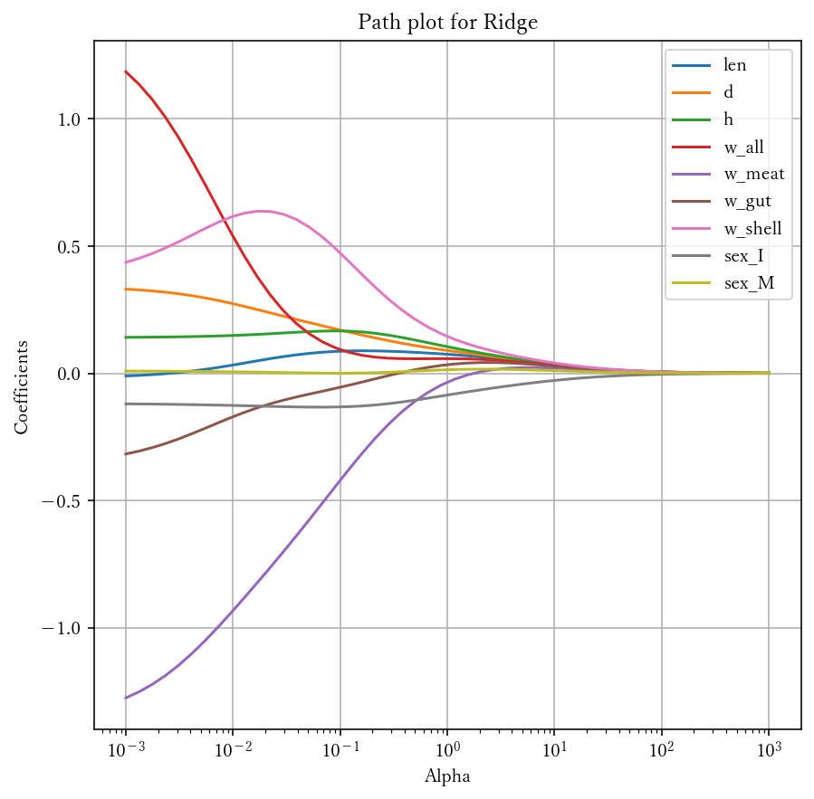

```python
ret = []
for al in alphas:
    r = model.fit_regularized(L1_wt=0.0, alpha=al)
    ret.append(r.params)

df_ret = pd.DataFrame(ret, columns=dfX_scaled.columns, index=alphas)
display(df_ret.head())  # debug
df_ret.plot(figsize=(7,7))
plt.title('Path plot for Ridge')
plt.xlabel('Alpha')
plt.ylabel('Coefficients')
plt.xscale("log")
plt.grid(True)
```

##### LASSO

|  | len | d | h | w_all | w_meat | w_gut | w_shell | sex_I | sex_M |
| --- | --- | --- | --- | --- | --- | --- | --- | --- | --- |
| 0.001000 | 0.093326 | 0.273367 | 0.144263 | 0.244200 | -0.932110 | -0.096464 | 0.783479 | -0.129771 | 0.0 |
| 0.001326 | 0.088982 | 0.273705 | 0.144021 | 0.249840 | -0.929511 | -0.094298 | 0.777552 | -0.129312 | 0.0 |
| 0.001758 | 0.083171 | 0.274170 | 0.143679 | 0.256016 | -0.925623 | -0.091012 | 0.770211 | -0.128714 | 0.0 |
| 0.002330 | 0.075074 | 0.274855 | 0.143164 | 0.257191 | -0.917623 | -0.084561 | 0.763084 | -0.127968 | 0.0 |
| 0.003089 | 0.038985 | 0.279122 | 0.142077 | 0.000000 | -0.767643 | 0.000000 | 0.828663 | -0.127514 | 0.0 |

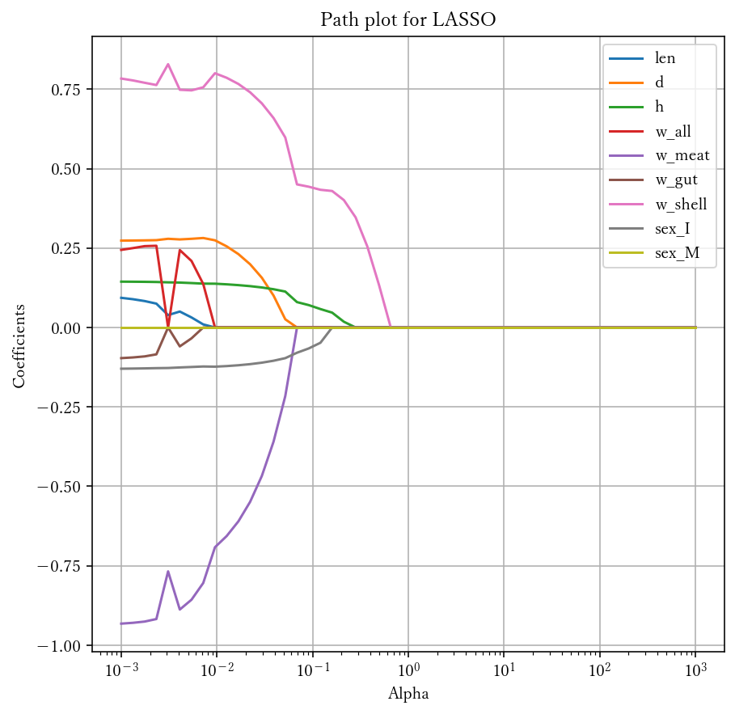

```python
ret = []
for al in alphas:
    r = model.fit_regularized(L1_wt=1.0, alpha=al)
    ret.append(r.params)

df_ret = pd.DataFrame(ret, columns=dfX_scaled.columns, index=alphas)
display(df_ret.head())  # debug
df_ret.plot(figsize=(7,7))
plt.title('Path plot for LASSO')
plt.xlabel('Alpha')
plt.ylabel('Coefficients')
plt.xscale("log")
plt.grid(True)
```

##### Elastic Net

|  | len | d | h | w_all | w_meat | w_gut | w_shell | sex_I | sex_M |
| --- | --- | --- | --- | --- | --- | --- | --- | --- | --- |
| 0.001000 | 0.098688 | 0.272577 | 0.145057 | 0.236040 | -0.931374 | -0.099993 | 0.788777 | -0.130514 | 0.0 |
| 0.001326 | 0.096248 | 0.272603 | 0.145106 | 0.240696 | -0.929103 | -0.099610 | 0.783942 | -0.130285 | 0.0 |
| 0.001758 | 0.093215 | 0.272590 | 0.145205 | 0.248581 | -0.926685 | -0.099800 | 0.776896 | -0.129971 | 0.0 |
| 0.002330 | 0.088890 | 0.272595 | 0.145262 | 0.255202 | -0.922121 | -0.098649 | 0.769048 | -0.129579 | 0.0 |
| 0.003089 | 0.082918 | 0.272579 | 0.145282 | 0.258819 | -0.914011 | -0.095570 | 0.760610 | -0.129097 | 0.0 |

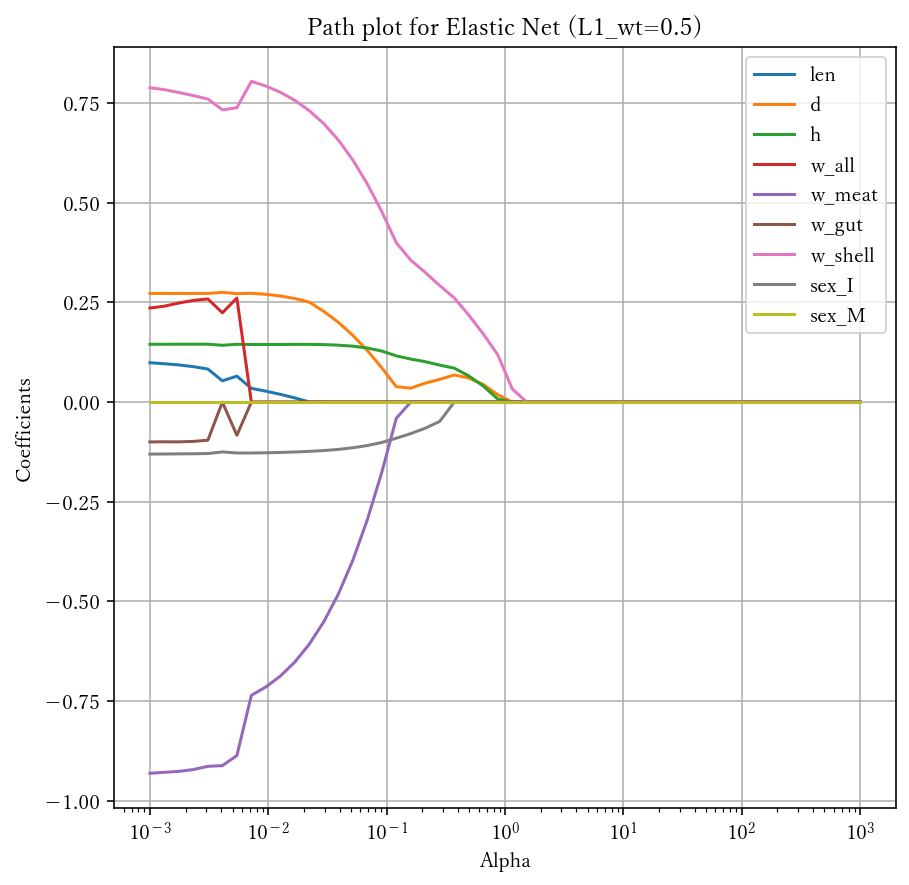

```python
ret = []
for al in alphas:
    r = model.fit_regularized(L1_wt=0.5, alpha=al)
    ret.append(r.params)

df_ret = pd.DataFrame(ret, columns=dfX_scaled.columns, index=alphas)
display(df_ret.head())  # debug
df_ret.plot(figsize=(7,7))
plt.title('Path plot for Elastic Net (L1_wt=0.5)')
plt.xlabel('Alpha')
plt.ylabel('Coefficients')
plt.xscale("log")
plt.grid(True)
```